# Prelim Bayesian reassurance outputs

Trent Henderson

07/05/2020

## About this document

This is a summary of initial Bayesian statistical models which aim to explore predictors of reassurance activation in three regions of the brain:

1. Amygdala
2. Medial prefrontal cortex (MPFC)
3. Auditory cortex (AI)

The predictors used in the models included:

- Stress (DASS)
- Inadequate forms criticism
- Fear of expressing compassion to self

## Results

This section is organised according to the three brain region activation response variables.

### Amygdala reassurance

Posterior distributions of the predictors.

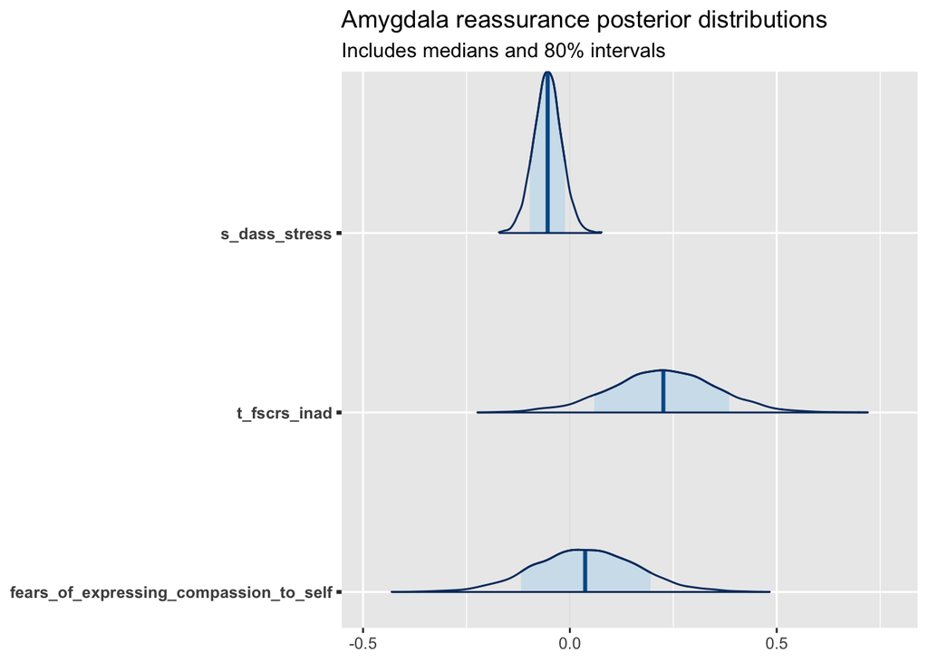

A sample of posterior draws highlight an interesting pattern.

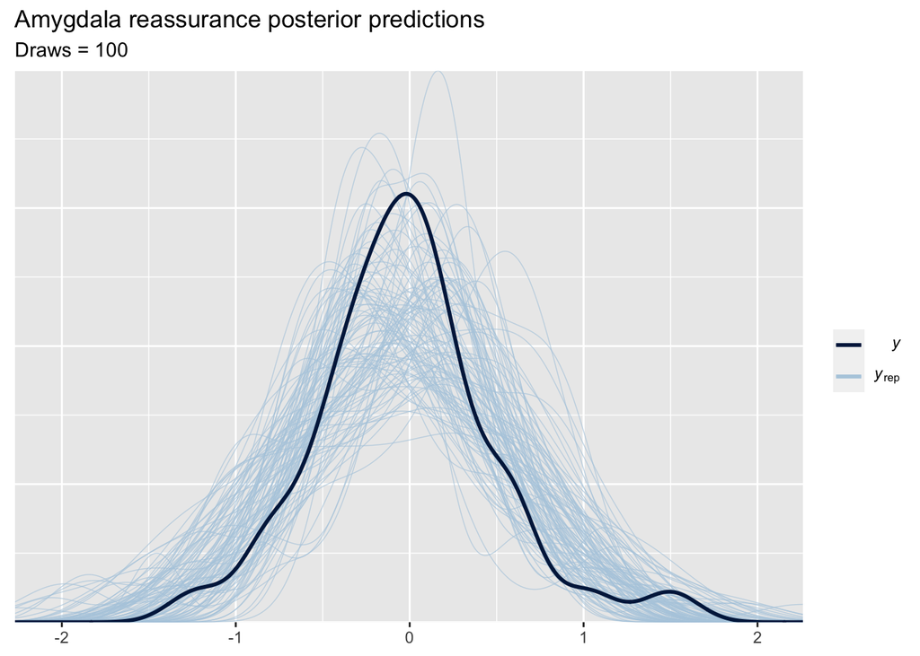

Bayesian uncertainty intervals suggest none of the predictors explain amygdala reassurance.

```
##                                               2.5%      97.5%
## s_dass_stress                          -0.12142732 0.01289236
## t_fscrs_inad                           -0.03596532 0.47189212
## fears_of_expressing_compassion_to_self -0.20865654 0.28687270
```

### MPFC

Posterior distributions of the predictors.

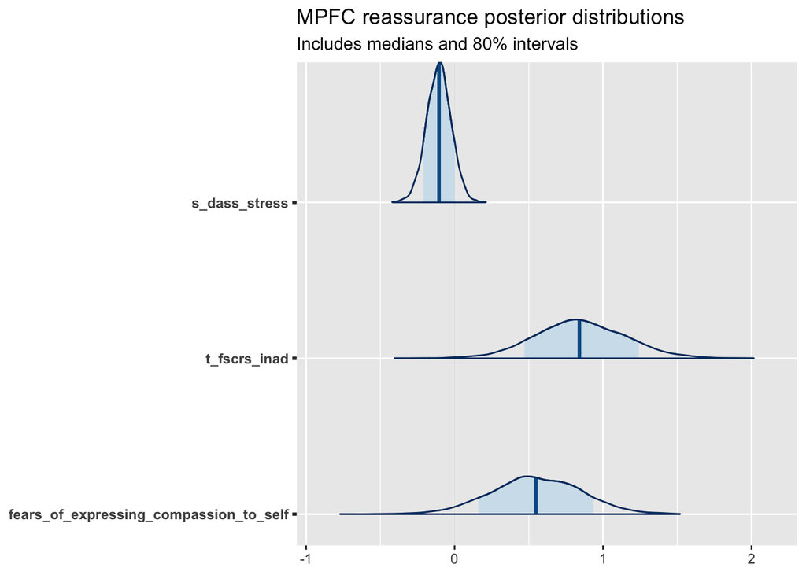

A sample of posterior draws highlight an interesting pattern.

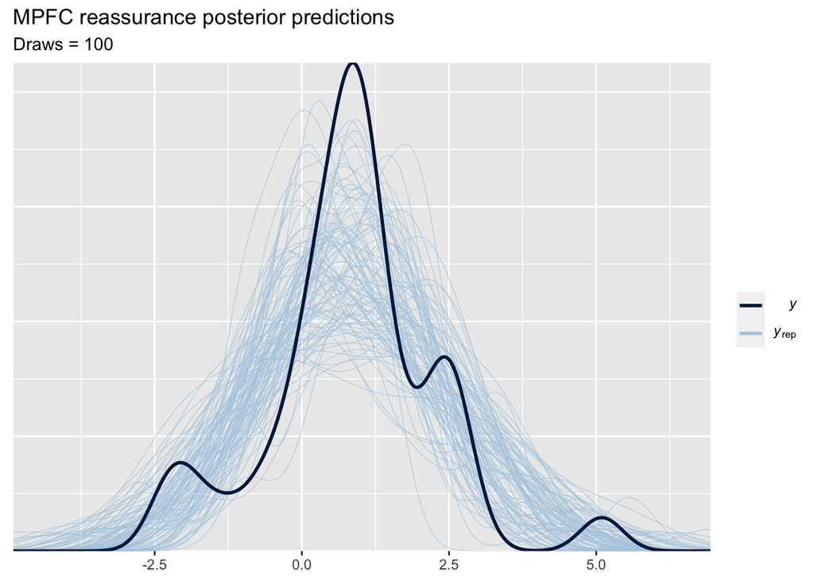

Bayesian uncertainty intervals suggest that there is essentially zero probability that inadequate forms of criticism is < 0.

```
##                                              2.5%      97.5%
## s_dass_stress                          -0.2726614 0.05779039
## t_fscrs_inad                            0.2660882 1.45575678
## fears_of_expressing_compassion_to_self -0.0465613 1.14342877
```

Model criticisms show that there aren’t many outliers outside the 0.5 threshold which may impact the model.

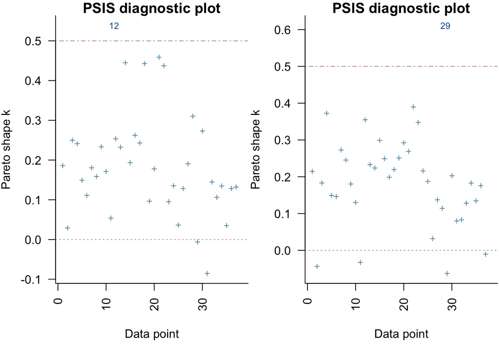

### AI

Posterior distributions of the predictors.

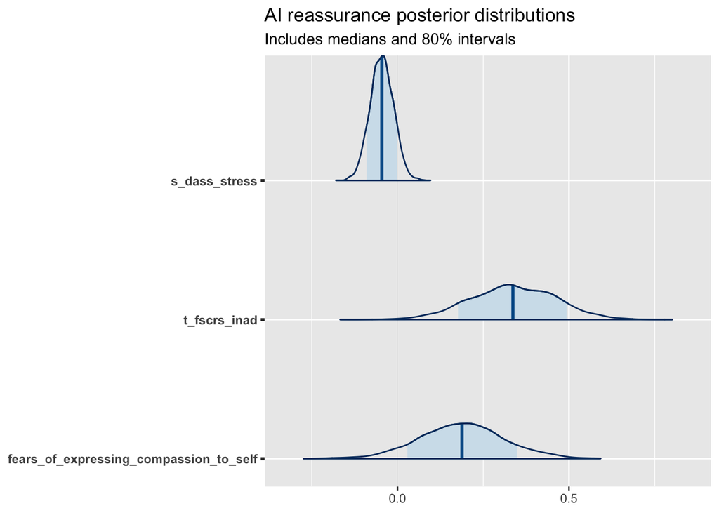

A sample of posterior draws highlight an interesting pattern.

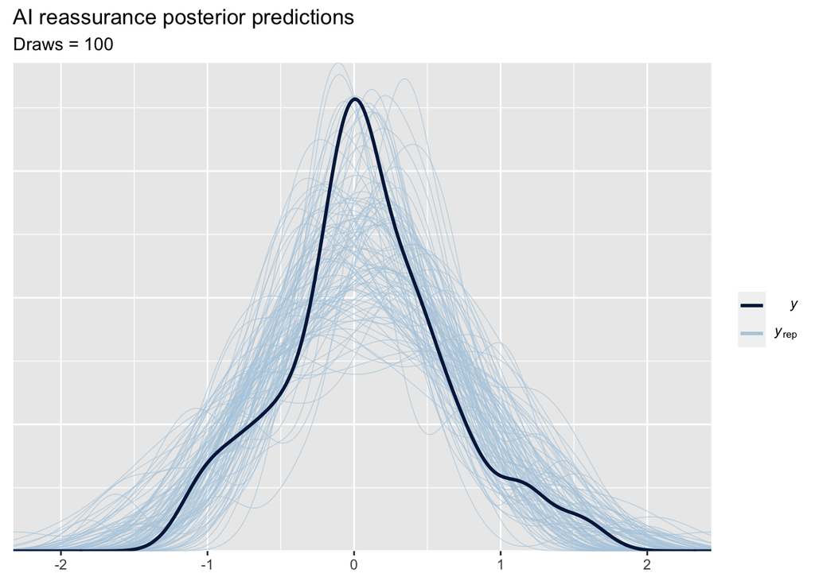

Bayesian uncertainty intervals suggest that there is essentially zero probability that inadequate forms of criticism is < 0.

```
##                                               2.5%      97.5%
## s_dass_stress                          -0.11256289 0.02056467
## t_fscrs_inad                            0.09013301 0.58081769
## fears_of_expressing_compassion_to_self -0.05610782 0.43918948
```

Model criticisms show that there aren’t many outliers outside the 0.5 threshold which may impact the model.

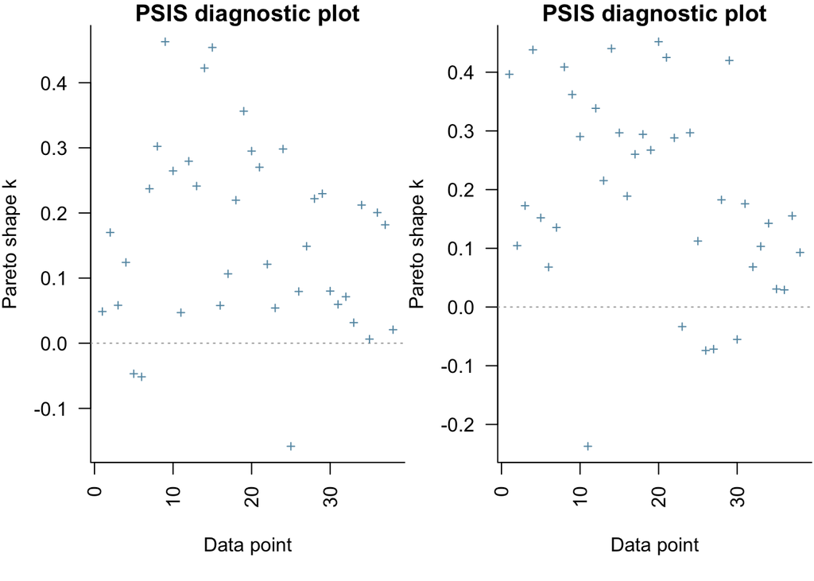

## Next steps

Frequentist analysis using Generalised Additive Models (GAM) have also be completed. It will be determined whether this or the Bayesian approach should be used.